# Homework 3

Ashley Miller

2024-11-7

## Sampler Stubs

Below is code to get you started finishing the Gibbs Sampler I’ve asked you to complete in Homework 3. You can, and should, copy paste the entire codeblock into your Rmd, and complete appropriate lines. Remember to change the data load statements to be appropriate to your file system.

```r
#Make sure you install the Rmpfr library
library(Rmpfr)
library(tidyverse)
dat = read.csv("coaldisasters-ds6040.csv")


gibbs_sampler = function(iter, dat, a_mu, b_mu, a_lambda, b_lambda){

  mu_vec = vector()
  lambda_vec = vector()
  k_prob_mat = matrix(nrow = iter+1, ncol = 111)
  k_samp_vec = vector()
  #Initialize sampler
    mu_vec[1] = rgamma(1,a_mu, rate  = b_mu)
  lambda_vec[1] = rgamma(1,a_lambda, rate = b_lambda)
  k_prob_mat[1,] = rep(1/111, 111)
  k_samp_vec[1] = 56

  #Sampler
  for(i in 2:(iter+1)){
    mu_vec[i] = rgamma(1, a_mu + sum(dat[1:k_samp_vec[i - 1], 2]), rate = b_mu + k_samp_vec[i - 1])
    lambda_vec[i] = rgamma(1, a_lambda + sum(dat[(k_samp_vec[i - 1] + 1):112, 2]), rate = b_lambda + (112 - k_samp_vec[i - 1]))


    l_temp = vector()
  for(j in 1:111){
    l_temp[j] = sum(log(mpfr(dpois(dat[1:j,2], lambda = rep(mu_vec[i],j)), precBits = 100))) + sum(log(mpfr(dpois(dat[(j+1):112,2], lambda = rep(lambda_vec[i],112-j)), precBits = 100)))
  }
  l_temp <- mpfr(l_temp, precBits = 100)
  k_prob_mat[i,] = as.numeric(exp(l_temp)/sum(exp(l_temp)))
  k_samp_vec[i] = sample(size = 1,1:111, prob = k_prob_mat[i,])
  }
  toReturn = data.frame(mu = mu_vec, lambda = lambda_vec, k = k_samp_vec)

  return(toReturn)
}
set.seed(666)
test = gibbs_sampler(1000, dat, a_mu = 1, b_mu = 1, a_lambda = 1, b_lambda = 1)
```

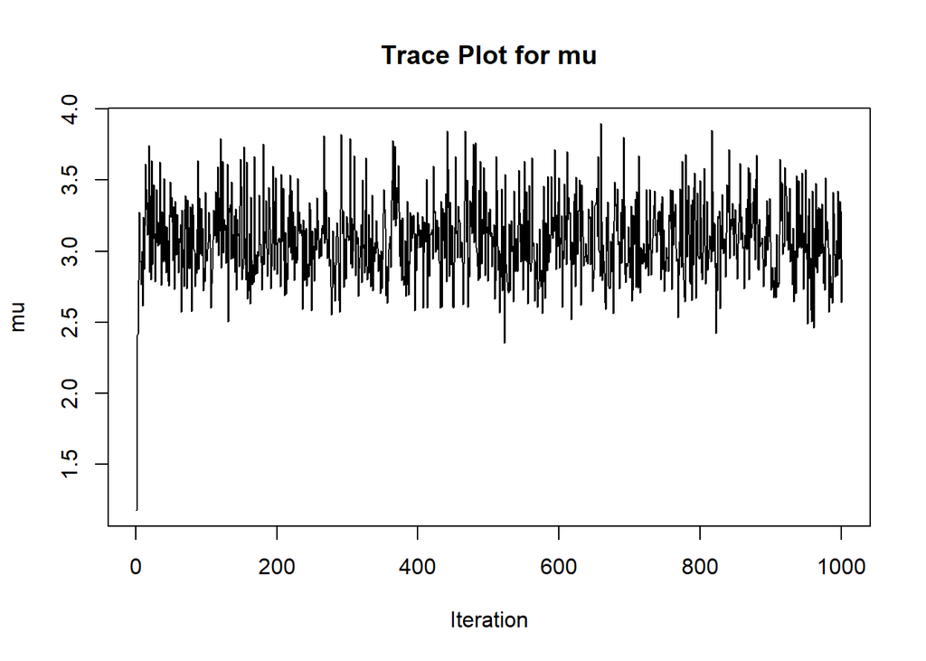

```r
plot(test$mu, type = 'l', main = 'Trace Plot for mu', ylab = 'mu', xlab = 'Iteration')
```

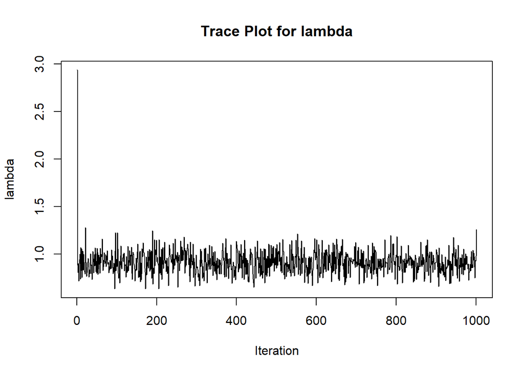

```r
plot(test$lambda, type = 'l', main = 'Trace Plot for lambda', ylab = 'lambda', xlab = 'Iteration')
```

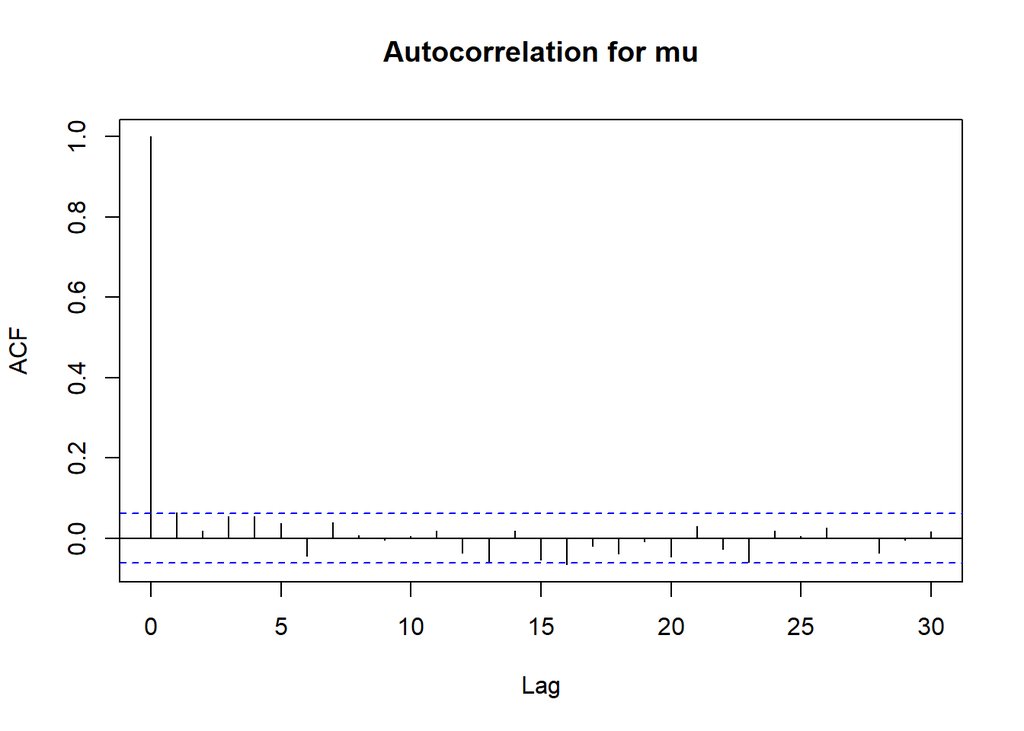

```r
acf(test$mu, main = 'Autocorrelation for mu')
```

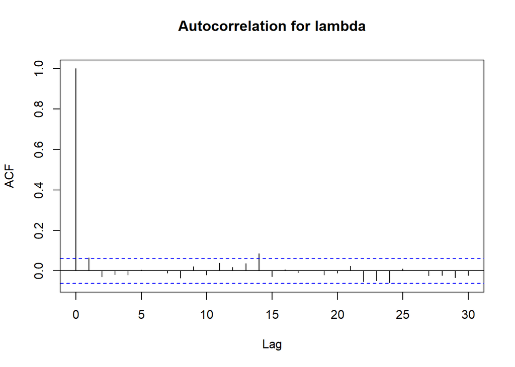

```r
acf(test$lambda, main = 'Autocorrelation for lambda')
```

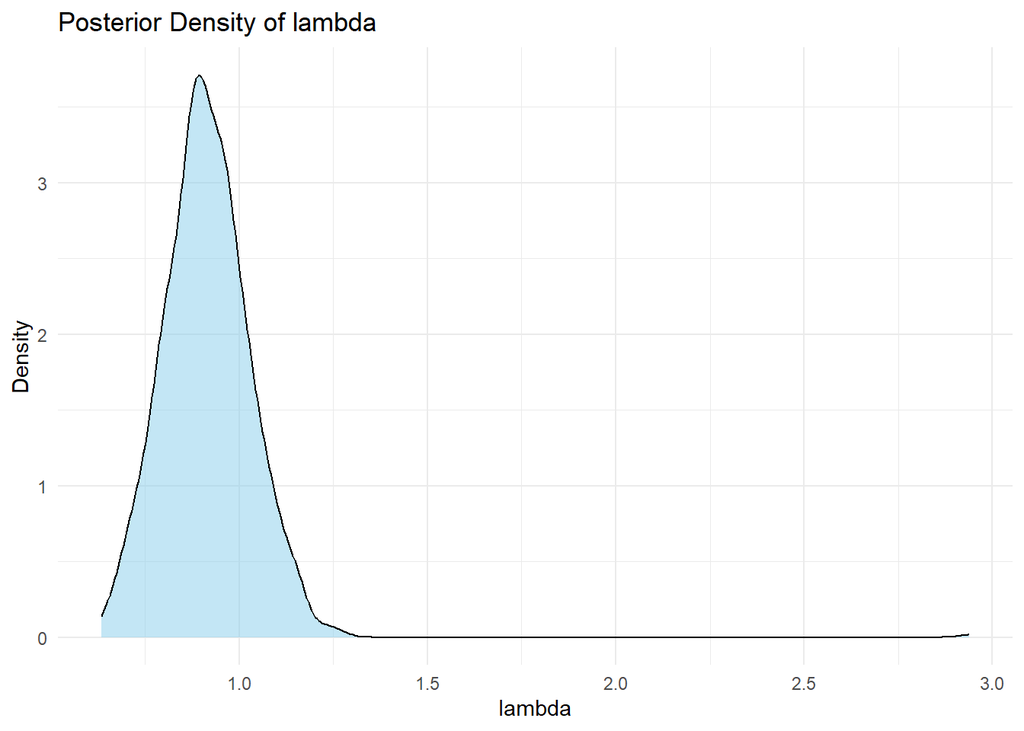

```r
ggplot(test, aes(x = lambda)) +
  geom_density(fill = "skyblue", alpha = 0.5) +
  labs(title = "Posterior Density of lambda", x = "lambda", y = "Density") +
  theme_minimal()
```

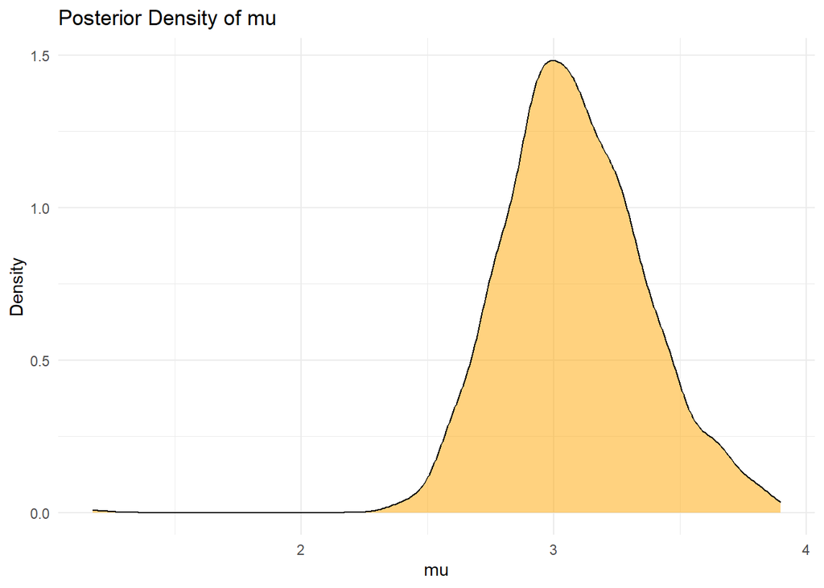

```r
ggplot(test, aes(x = mu)) +
  geom_density(fill = "orange", alpha = 0.5) +
  labs(title = "Posterior Density of mu", x = "mu", y = "Density") +
  theme_minimal()
```

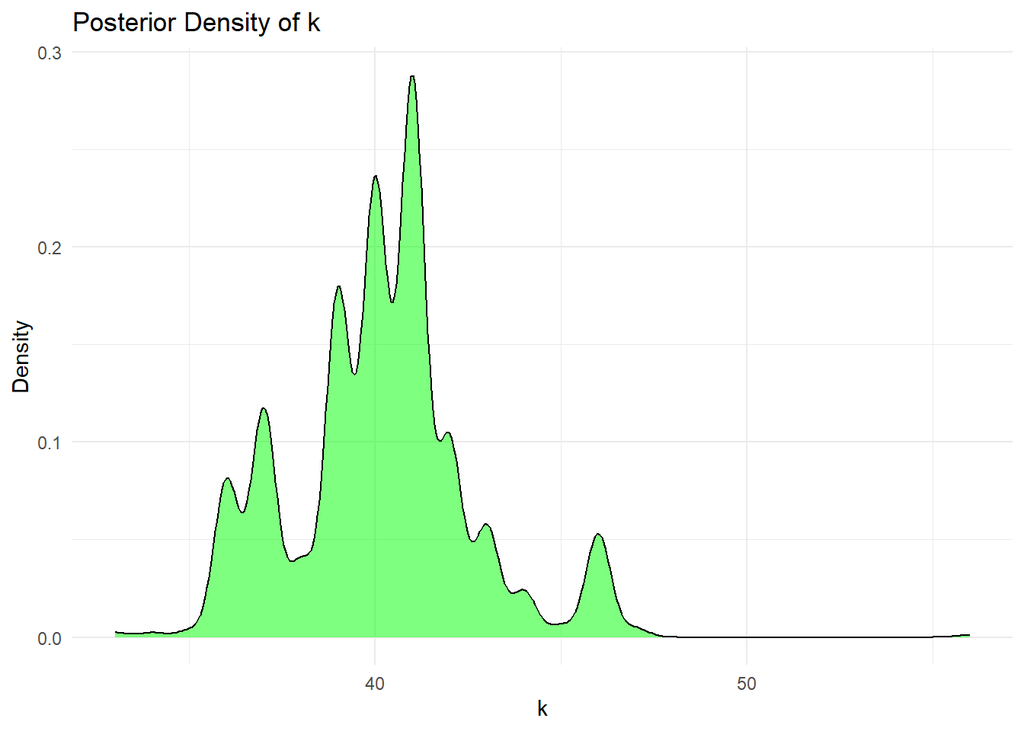

```r
ggplot(test, aes(x = k)) +
  geom_density(fill = "green", alpha = 0.5) +
  labs(title = "Posterior Density of k", x = "k", y = "Density") +
  theme_minimal()
```

```r
eap_mu <- mean(test$mu)
eap_lambda <- mean(test$lambda)

credible_interval_mu <- quantile(test$mu, c(0.025, 0.975))
credible_interval_lambda <- quantile(test$lambda, c(0.025, 0.975))

k_freq <- table(test$k)
sorted_k <- sort(k_freq, decreasing = TRUE)
top_5_k <- as.numeric(names(sorted_k)[1:5])


results <- data.frame( Parameter = c("mu", "mu", "lambda", "lambda", "Top 5 k values"),
                       Measure = c("EAP", "95% CI", "EAP", "95% CI", "Values"),
                       Value = c( eap_mu, paste(credible_interval_mu, collapse = " - "),
                                  eap_lambda, paste(credible_interval_lambda, collapse = " - "),
                                  paste(top_5_k, collapse = ", ") ) )

print(results)
```

```
##        Parameter Measure                                Value
## 1             mu     EAP                     3.08052614942352
## 2             mu  95% CI   2.59943587551145 - 3.6658827637961
## 3         lambda     EAP                    0.914490997226666
## 4         lambda  95% CI 0.698106912724644 - 1.14683059273923
## 5 Top 5 k values  Values                   41, 40, 39, 37, 42
```

1.a The EAP for mu implies that before the changepoint, there were on average ~3.1 accidents in a year, with a 95% degree of credibility to be within ~2.6 and ~3.7 accidents in a year. The EAP for lambda implies that after the changepoint, there was on average ~.9 accidents, with a 95% degree of credibility to be within ~.7 and ~1.1 accidents. The most likely time of the changepoint found in the 1000 sampling iterations was between 1891 and 1892 (after the 41st year).

1.b This would be inappropriate to report for the changepoint because the year of the change is a discrete variable and could very well end up being a non-integer value, which doesn’t make sense in our framework of the model.

```r
library(Rmpfr)
gibbs_sampler_met = function(iter, dat, a_mu, b_mu, a_lambda, b_lambda){

  mu_vec = vector()
  lambda_vec = vector()
  k_samp_vec = vector()
  #Initialize sampler
  mu_vec[1] = rgamma(1,a_mu, rate  = b_mu)
  lambda_vec[1] = rgamma(1,a_lambda, rate = b_lambda)
  k_samp_vec[1] = 56

  #Sampler
  for(i in 2:(iter+1)){
    mu_vec[i] = rgamma(1, a_mu + sum(dat[1:k_samp_vec[i - 1], 2]), rate = b_mu + k_samp_vec[i - 1])
    lambda_vec[i] = rgamma(1, a_lambda + sum(dat[(k_samp_vec[i - 1] + 1):112, 2]), rate = b_lambda + (112 - k_samp_vec[i - 1]))

    k_proposal <- sample(1:112, 1)
    k_current <- k_samp_vec[i - 1]


    log_posterior_current <- sum(log(mpfr(dpois(dat[1:k_current, 2], lambda = rep(mu_vec[i], k_current)), precBits = 100))) +
      sum(log(mpfr(dpois(dat[(k_current + 1):112, 2], lambda = rep(lambda_vec[i], 112 - k_current)), precBits = 100)))

    log_posterior_proposal <- sum(log(mpfr(dpois(dat[1:k_proposal, 2], lambda = rep(mu_vec[i], k_proposal)), precBits = 100))) +
      sum(log(mpfr(dpois(dat[(k_proposal + 1):112, 2], lambda = rep(lambda_vec[i], 112 - k_proposal)), precBits = 100)))


    acceptance_ratio <- exp(log_posterior_proposal - log_posterior_current)


    if (runif(1) < acceptance_ratio) {
      k_samp_vec[i] <- k_proposal
    } else {
      k_samp_vec[i] <- k_current
    }
  }
  toReturn = data.frame(mu = mu_vec, lambda = lambda_vec, k = k_samp_vec)

  return(toReturn)
}
set.seed(666)
test_met = gibbs_sampler_met(1000, dat, a_mu = 1, b_mu = 1, a_lambda = 1, b_lambda = 1)
```

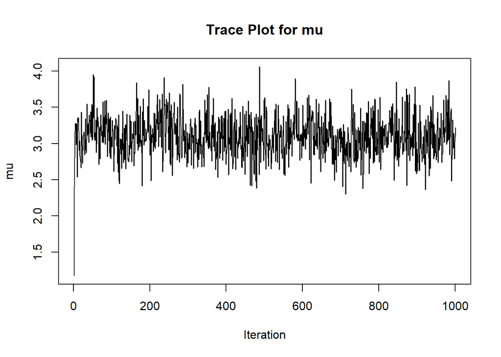

```r
plot(test_met$mu, type = 'l', main = 'Trace Plot for mu', ylab = 'mu', xlab = 'Iteration')
```

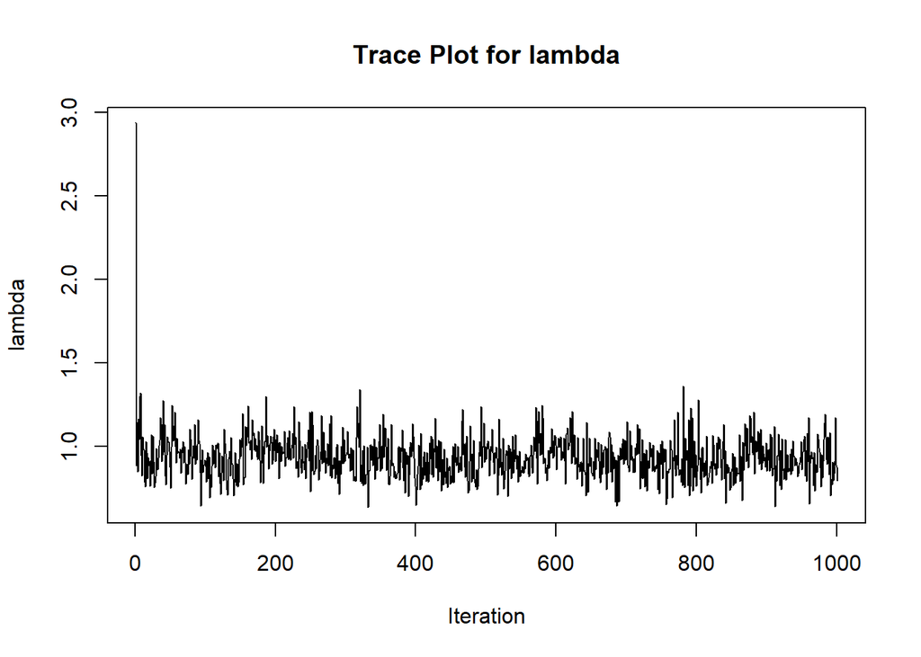

```r
plot(test_met$lambda, type = 'l', main = 'Trace Plot for lambda', ylab = 'lambda', xlab = 'Iteration')
```

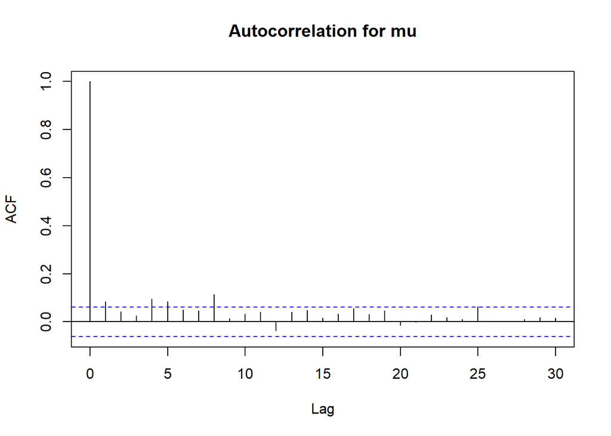

```r
acf(test_met$mu, main = 'Autocorrelation for mu')
```

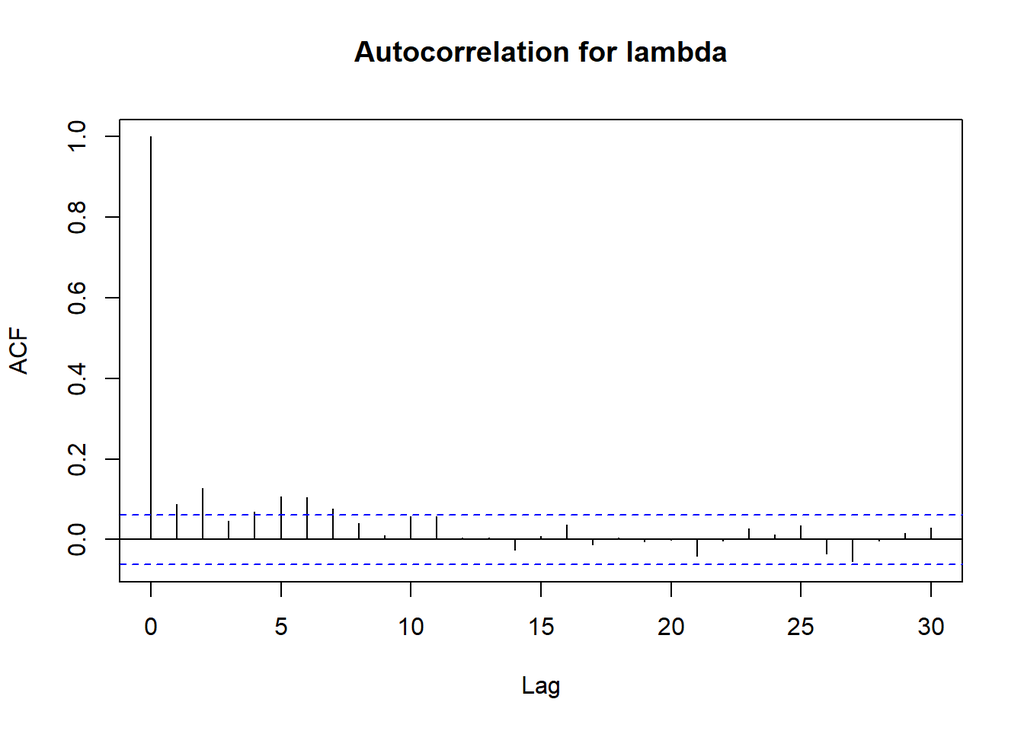

```r
acf(test_met$lambda, main = 'Autocorrelation for lambda')
```

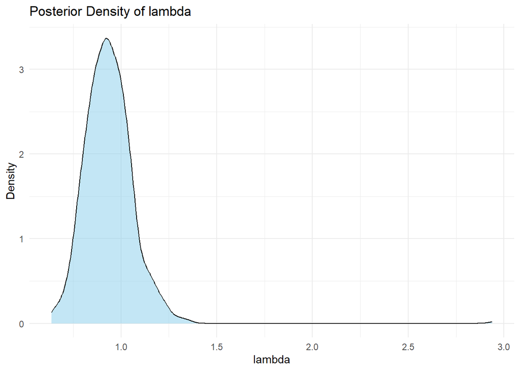

```r
ggplot(test_met, aes(x = lambda)) +
  geom_density(fill = "skyblue", alpha = 0.5) +
  labs(title = "Posterior Density of lambda", x = "lambda", y = "Density") +
  theme_minimal()
```

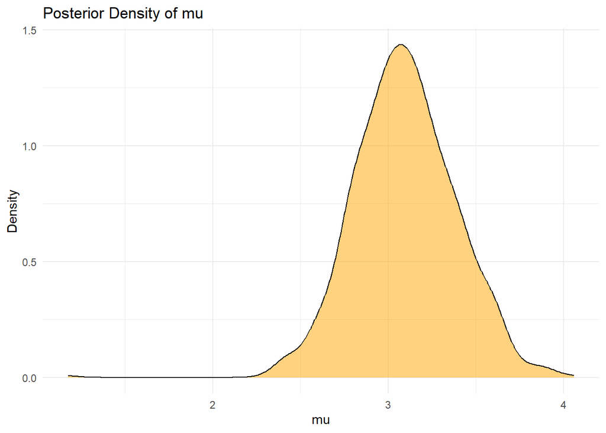

```r
ggplot(test_met, aes(x = mu)) +
  geom_density(fill = "orange", alpha = 0.5) +
  labs(title = "Posterior Density of mu", x = "mu", y = "Density") +
  theme_minimal()
```

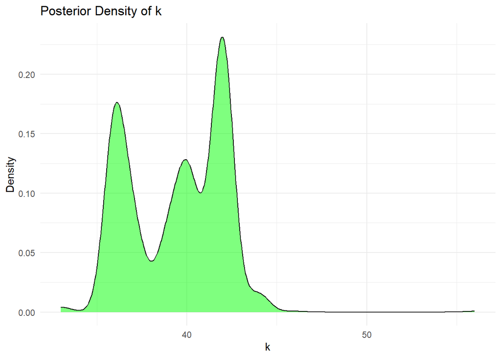

```r
ggplot(test_met, aes(x = k)) +
  geom_density(fill = "green", alpha = 0.5) +
  labs(title = "Posterior Density of k", x = "k", y = "Density") +
  theme_minimal()
```

```r
eap_mu_met <- mean(test_met$mu)
eap_lambda_met <- mean(test_met$lambda)

credible_interval_mu_met <- quantile(test_met$mu, c(0.025, 0.975))
credible_interval_lambda_met <- quantile(test_met$lambda, c(0.025, 0.975))

k_freq <- table(test_met$k)
sorted_k <- sort(k_freq, decreasing = TRUE)
top_5_k <- as.numeric(names(sorted_k)[1:5])


results_met <- data.frame( Parameter = c("mu", "mu", "lambda", "lambda", "Top 5 k values"),
                       Measure = c("EAP", "95% CI", "EAP", "95% CI", "Values"),
                       Value = c( eap_mu_met, paste(credible_interval_mu_met, collapse = " - "),
                                  eap_lambda_met, paste(credible_interval_lambda_met, collapse = " - "),
                                  paste(top_5_k, collapse = ", ") ) )

print(results_met)
```

```
##        Parameter Measure                                Value
## 1             mu     EAP                     3.09632819876229
## 2             mu  95% CI  2.56545546749533 - 3.64615765623242
## 3         lambda     EAP                    0.936003235639666
## 4         lambda  95% CI 0.721615643337917 - 1.19318843970847
## 5 Top 5 k values  Values                   42, 36, 40, 37, 39
```

With the implementation above, the EAP values for both mu and lambda are nearly the same as the pure Gibbs sampler. We also had a most likely changepoint value that was within 1 of the other method. The other probable changepoint values were not all the same, either. I would imagine that this is due to the randomness by which k’s were proposed, leading there to be variability in the highly probable spaces explored. One issue with this implementation is that there is no guarantee that the convergence will happen with lower iterations. If there is an area of low acceptance probability being traversed, this would slow the convergence down. This could also have a hard time converging if the most probable values of k were highly dense and restricted to a smaller area.

```r
gibbs_sampler_met = function(iter, dat, a_mu, b_mu, a_lambda, b_lambda){

  mu_vec = vector()
  lambda_vec = vector()
  k_samp_vec = vector()
  #Initialize sampler
  mu_vec[1] = rgamma(1,a_mu, rate  = b_mu)
  lambda_vec[1] = rgamma(1,a_lambda, rate = b_lambda)
  k_samp_vec[1] = 56

  #Sampler
  for(i in 2:(iter+1)){
    mu_vec[i] = rgamma(1, a_mu + sum(dat[1:k_samp_vec[i - 1], 2]), rate = b_mu + k_samp_vec[i - 1])
    lambda_vec[i] = rgamma(1, a_lambda + sum(dat[(k_samp_vec[i - 1] + 1):112, 2]), rate = b_lambda + (112 - k_samp_vec[i - 1]))

    k_current <- k_samp_vec[i - 1]
    k_proposal <- k_current + sample(c(-1, 1), 1)
    if (k_proposal < 1) k_proposal <- 1
    if (k_proposal > 112) k_proposal <- 112


    log_posterior_current <- sum(log(mpfr(dpois(dat[1:k_current, 2], lambda = rep(mu_vec[i], k_current)), precBits = 100))) +
      sum(log(mpfr(dpois(dat[(k_current + 1):112, 2], lambda = rep(lambda_vec[i], 112 - k_current)), precBits = 100)))

    log_posterior_proposal <- sum(log(mpfr(dpois(dat[1:k_proposal, 2], lambda = rep(mu_vec[i], k_proposal)), precBits = 100))) +
      sum(log(mpfr(dpois(dat[(k_proposal + 1):112, 2], lambda = rep(lambda_vec[i], 112 - k_proposal)), precBits = 100)))


    acceptance_ratio <- exp(log_posterior_proposal - log_posterior_current)


    if (runif(1) < acceptance_ratio) {
      k_samp_vec[i] <- k_proposal
    } else {
      k_samp_vec[i] <- k_current
    }
  }
  toReturn = data.frame(mu = mu_vec, lambda = lambda_vec, k = k_samp_vec)

  return(toReturn)
}
set.seed(666)
test_met = gibbs_sampler_met(1000, dat, a_mu = 1, b_mu = 1, a_lambda = 1, b_lambda = 1)
```

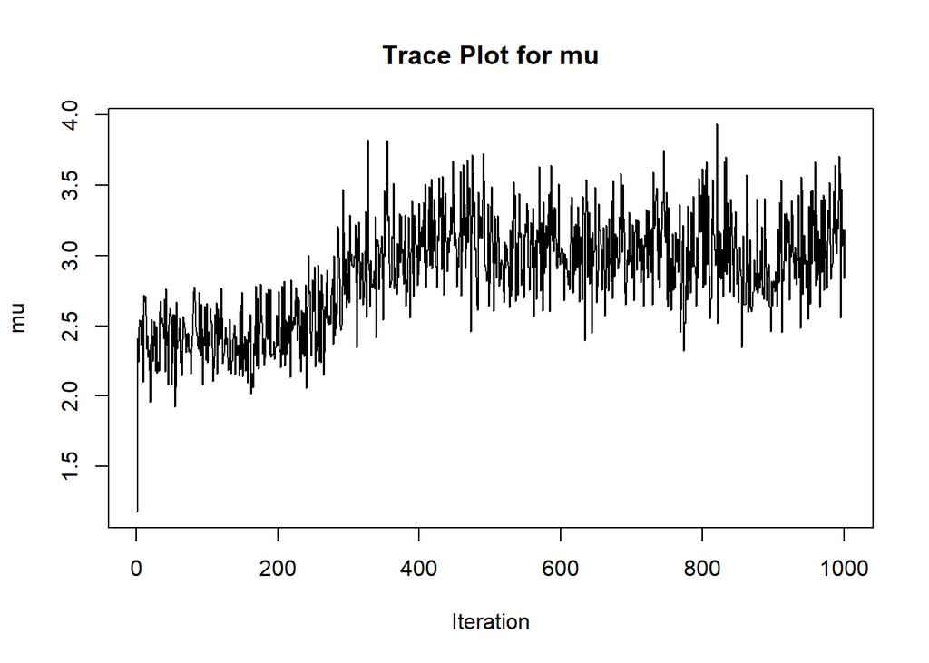

```r
plot(test_met$mu, type = 'l', main = 'Trace Plot for mu', ylab = 'mu', xlab = 'Iteration')
```

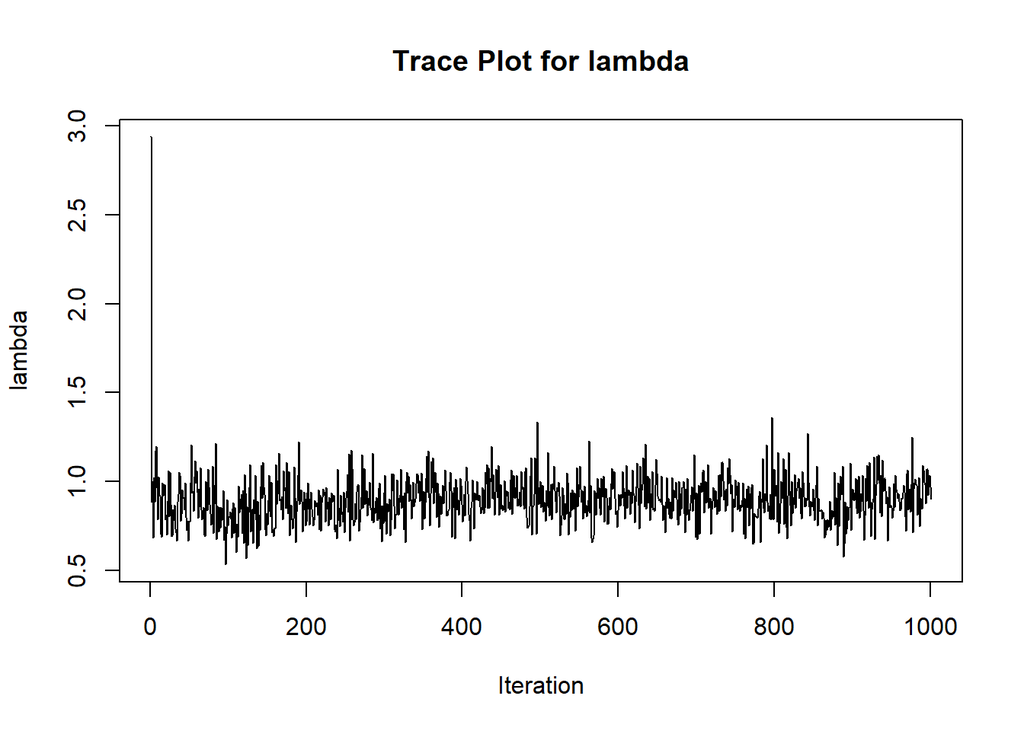

```r
plot(test_met$lambda, type = 'l', main = 'Trace Plot for lambda', ylab = 'lambda', xlab = 'Iteration')
```

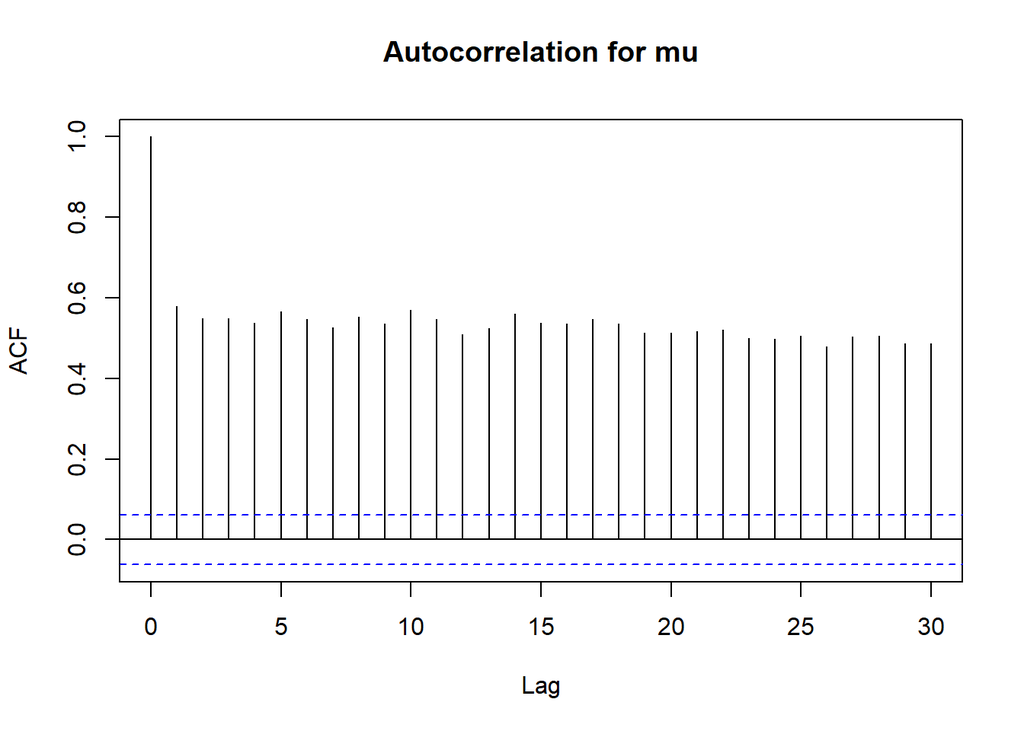

```r
acf(test_met$mu, main = 'Autocorrelation for mu')
```

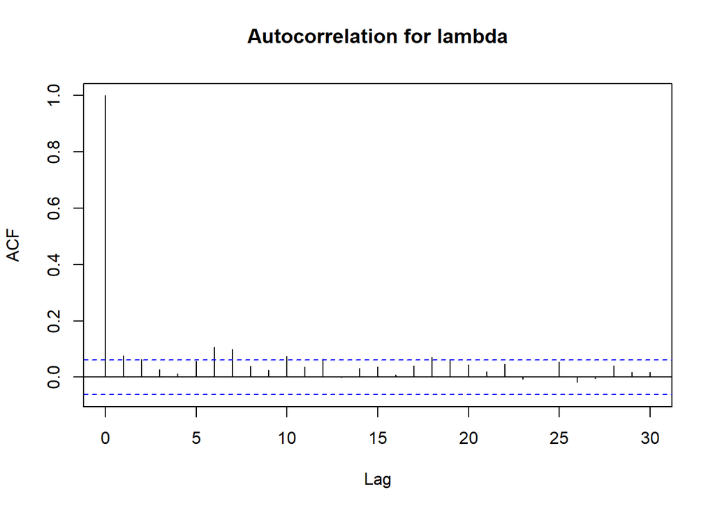

```r
acf(test_met$lambda, main = 'Autocorrelation for lambda')
```

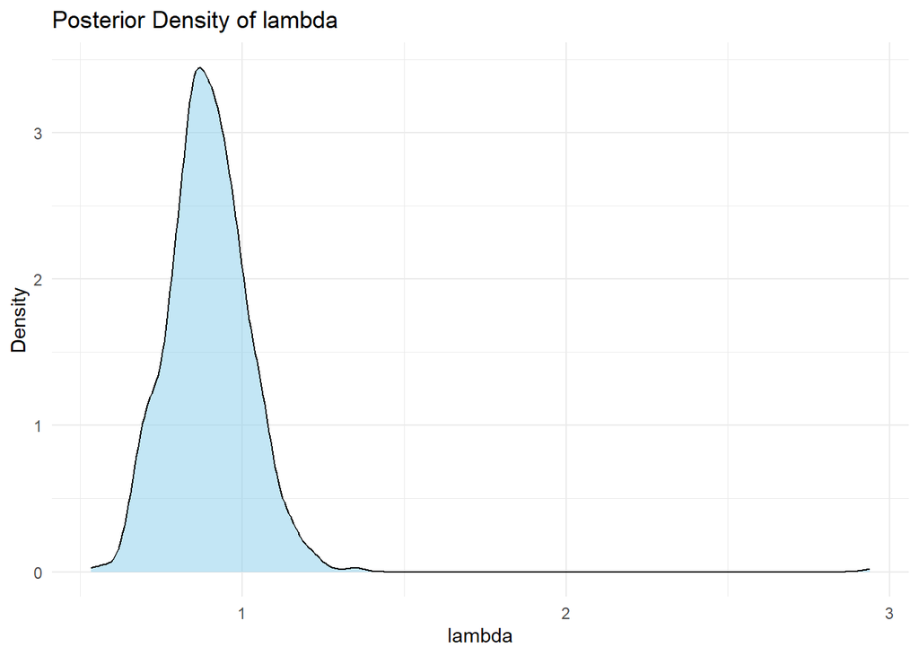

```r
ggplot(test_met, aes(x = lambda)) +
  geom_density(fill = "skyblue", alpha = 0.5) +
  labs(title = "Posterior Density of lambda", x = "lambda", y = "Density") +
  theme_minimal()
```

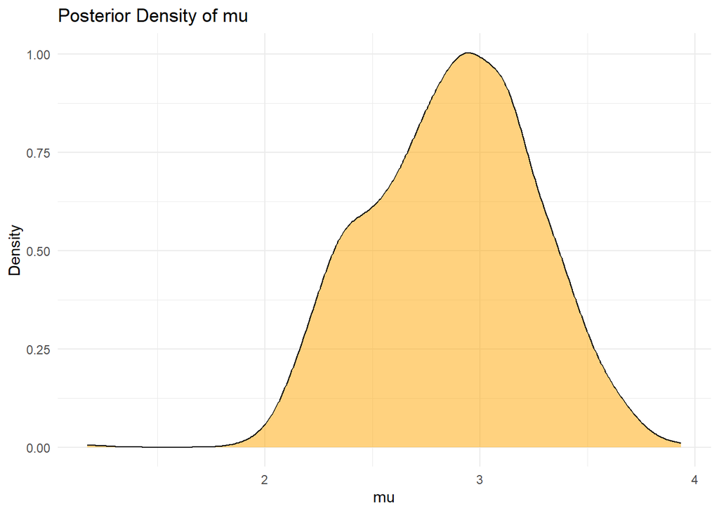

```r
ggplot(test_met, aes(x = mu)) +
  geom_density(fill = "orange", alpha = 0.5) +
  labs(title = "Posterior Density of mu", x = "mu", y = "Density") +
  theme_minimal()
```

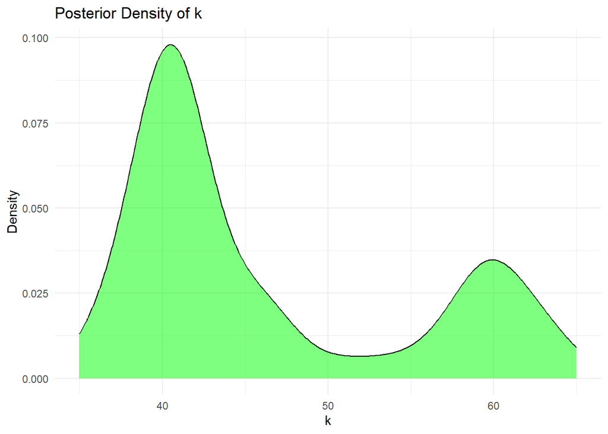

```r
ggplot(test_met, aes(x = k)) +
  geom_density(fill = "green", alpha = 0.5) +
  labs(title = "Posterior Density of k", x = "k", y = "Density") +
  theme_minimal()
```

```r
eap_mu_met <- mean(test_met$mu)
eap_lambda_met <- mean(test_met$lambda)

credible_interval_mu_met <- quantile(test_met$mu, c(0.025, 0.975))
credible_interval_lambda_met <- quantile(test_met$lambda, c(0.025, 0.975))

k_freq <- table(test_met$k)
sorted_k <- sort(k_freq, decreasing = TRUE)
top_5_k <- as.numeric(names(sorted_k)[1:5])


results_met <- data.frame( Parameter = c("mu", "mu", "lambda", "lambda", "Top 5 k values"),
                       Measure = c("EAP", "95% CI", "EAP", "95% CI", "Values"),
                       Value = c( eap_mu_met, paste(credible_interval_mu_met, collapse = " - "),
                                  eap_lambda_met, paste(credible_interval_lambda_met, collapse = " - "),
                                  paste(top_5_k, collapse = ", ") ) )

print(results_met)
```

```
##        Parameter Measure                                Value
## 1             mu     EAP                     2.87160662455425
## 2             mu  95% CI  2.17445201217285 - 3.56488160306722
## 3         lambda     EAP                    0.896442331594916
## 4         lambda  95% CI 0.674172876849355 - 1.14069593718606
## 5 Top 5 k values  Values                   41, 40, 39, 60, 46
```

```r
library(brms)
```

```r
library(bayesplot)
ww_tr = read.csv("whitewine-training-ds6040-1.csv")
ww_ts = read.csv("whitewine-testing-ds6040.csv")
```

```r
ww_tr <- ww_tr %>%
  mutate(wine_quality = ifelse(wine_quality =='A', 1, 0))
ww_ts <- ww_ts %>%
  mutate(wine_quality = ifelse(wine_quality =='A', 1, 0))
```

```r
set.seed(666)
priors <- c(
  set_prior("normal(0, 5)", class = "b"),
  set_prior("normal(0, 5)", class = "Intercept")
)
f_mod = brm(wine_quality ~ ., data = ww_tr, prior = priors,
            family = bernoulli(), cores = 12, seed = 666)
priors <- c(
  set_prior("normal(0, 2.5)", class = "b"),
  set_prior("normal(1, 5)", class = "Intercept")
)
f_a_mod = brm(wine_quality ~ ., data = ww_tr[ww_tr$wine_quality==1, ], prior = priors,
              family = bernoulli(), cores = 12, seed = 666)
summary(f_mod)
```

```
##  Family: bernoulli
##   Links: mu = logit
## Formula: wine_quality ~ fixed.acidity + volatile.acidity + citric.acid + residual.sugar + chlorides + free.sulfur.dioxide + total.sulfur.dioxide + density + pH + sulphates + alcohol
##    Data: ww_tr (Number of observations: 3178)
##   Draws: 4 chains, each with iter = 2000; warmup = 1000; thin = 1;
##          total post-warmup draws = 4000
##
## Regression Coefficients:
##                      Estimate Est.Error l-95% CI u-95% CI Rhat Bulk_ESS
## Intercept               -4.15      0.17    -4.48    -3.84 1.00     2937
## fixed.acidity            0.41      0.18     0.06     0.74 1.00     1434
## volatile.acidity        -0.32      0.13    -0.58    -0.06 1.00     3446
## citric.acid             -0.01      0.13    -0.29     0.24 1.00     3375
## residual.sugar           1.68      0.45     0.81     2.58 1.00     1187
## chlorides               -0.09      0.20    -0.51     0.23 1.00     3340
## free.sulfur.dioxide      0.37      0.14     0.10     0.65 1.00     2333
## total.sulfur.dioxide    -0.18      0.19    -0.57     0.19 1.00     2392
## density                 -2.02      0.71    -3.40    -0.63 1.00     1179
## pH                       0.52      0.16     0.21     0.84 1.00     1571
## sulphates                0.09      0.10    -0.10     0.29 1.00     2984
## alcohol                  0.18      0.35    -0.50     0.86 1.00     1409
##                      Tail_ESS
## Intercept                2897
## fixed.acidity            2008
## volatile.acidity         2352
## citric.acid              2869
## residual.sugar           1798
## chlorides                2283
## free.sulfur.dioxide      2721
## total.sulfur.dioxide     2530
## density                  1879
## pH                       2433
## sulphates                2645
## alcohol                  2344
##
## Draws were sampled using sampling(NUTS). For each parameter, Bulk_ESS
## and Tail_ESS are effective sample size measures, and Rhat is the potential
## scale reduction factor on split chains (at convergence, Rhat = 1).
```

```r
loo(f_mod)
```

```
##
## Computed from 4000 by 3178 log-likelihood matrix.
##
##          Estimate   SE
## elpd_loo   -396.6 30.8
## p_loo        12.4  1.5
## looic       793.1 61.6
## ------
## MCSE of elpd_loo is NA.
## MCSE and ESS estimates assume MCMC draws (r_eff in [0.3, 1.5]).
##
## Pareto k diagnostic values:
##                          Count Pct.    Min. ESS
## (-Inf, 0.7]   (good)     3177  100.0%  757
##    (0.7, 1]   (bad)         0    0.0%  <NA>
##    (1, Inf)   (very bad)    1    0.0%  <NA>
## See help('pareto-k-diagnostic') for details.
```

```r
waic(f_mod)
```

```
##
## Computed from 4000 by 3178 log-likelihood matrix.
##
##           Estimate   SE
## elpd_waic   -396.4 30.8
## p_waic        12.3  1.5
## waic         792.9 61.6
##
## 3 (0.1%) p_waic estimates greater than 0.4. We recommend trying loo instead.
```

2. Given the model above, the residual sugar, density, and pH are the best predictors when considering the whole dataset. Residual sugar and pH both have positive effects on the log-odds, and density has a negative effect. None of the three CI’s include zero, so there is credibility in the claim that they result in a change in odds of classifying a wine. The intercept also has a strong negative effect, and its CI does not include zero either. This means that when all other predictors are zero, there is a negative effect on the log odds of the wine being classified as A grade.

```r
summary(f_a_mod)
```

```
##  Family: bernoulli
##   Links: mu = logit
## Formula: wine_quality ~ fixed.acidity + volatile.acidity + citric.acid + residual.sugar + chlorides + free.sulfur.dioxide + total.sulfur.dioxide + density + pH + sulphates + alcohol
##    Data: ww_tr[ww_tr$wine_quality == 1, ] (Number of observations: 100)
##   Draws: 4 chains, each with iter = 2000; warmup = 1000; thin = 1;
##          total post-warmup draws = 4000
##
## Regression Coefficients:
##                      Estimate Est.Error l-95% CI u-95% CI Rhat Bulk_ESS
## Intercept               13.13      3.38     7.28    20.41 1.00     2076
## fixed.acidity           -0.24      1.81    -3.70     3.26 1.00     2872
## volatile.acidity         0.28      1.71    -3.00     3.71 1.00     2887
## citric.acid              0.09      1.87    -3.47     3.94 1.00     2898
## residual.sugar          -0.01      2.09    -4.13     4.09 1.00     3153
## chlorides                0.40      1.99    -3.16     4.53 1.00     3030
## free.sulfur.dioxide      0.14      1.71    -3.06     3.60 1.00     3076
## total.sulfur.dioxide     0.11      2.02    -3.78     4.08 1.00     3262
## density                  0.05      2.20    -4.12     4.50 1.00     2703
## pH                      -0.13      1.87    -3.77     3.45 1.00     3049
## sulphates                0.27      1.53    -2.39     3.58 1.00     2644
## alcohol                 -0.20      2.05    -4.25     3.69 1.00     2681
##                      Tail_ESS
## Intercept                2416
## fixed.acidity            2872
## volatile.acidity         2474
## citric.acid              2635
## residual.sugar           2945
## chlorides                2948
## free.sulfur.dioxide      2602
## total.sulfur.dioxide     2916
## density                  2666
## pH                       3113
## sulphates                2499
## alcohol                  2539
##
## Draws were sampled using sampling(NUTS). For each parameter, Bulk_ESS
## and Tail_ESS are effective sample size measures, and Rhat is the potential
## scale reduction factor on split chains (at convergence, Rhat = 1).
```

```r
loo(f_a_mod)
```

```
##
## Computed from 4000 by 100 log-likelihood matrix.
##
##          Estimate  SE
## elpd_loo     -0.9 0.1
## p_loo         0.4 0.1
## looic         1.8 0.3
## ------
## MCSE of elpd_loo is NA.
## MCSE and ESS estimates assume MCMC draws (r_eff in [0.6, 1.0]).
##
## Pareto k diagnostic values:
##                          Count Pct.    Min. ESS
## (-Inf, 0.7]   (good)     25    25.0%   3022
##    (0.7, 1]   (bad)      51    51.0%   <NA>
##    (1, Inf)   (very bad) 24    24.0%   <NA>
## See help('pareto-k-diagnostic') for details.
```

```r
waic(f_a_mod)
```

```
##
## Computed from 4000 by 100 log-likelihood matrix.
##
##           Estimate  SE
## elpd_waic     -0.8 0.1
## p_waic         0.3 0.1
## waic           1.6 0.2
```

In this A wines only model, the three largest effects are chlorides, volatile acidity, and sulphates. Their CI’s all include zero, which doesn’t allow us to make the same statements regarding their effects on the log odds of the wine’s classification. The intercept itself is truly the strongest predictor in this case, meaning that when all other predictors are equal to zero there is a positive effect on the log odds that the wine will be classified as an A wine (which we would expect given this “control” group of only A grade wines).

```r
set.seed(666)
priors <- c(
  set_prior("normal(0, 5)", class = "b"),
  set_prior("normal(0, 5)", class = "Intercept")
)
f_mod_s = brm(wine_quality ~ residual.sugar + density + pH, data = ww_tr, prior = priors,
            family = bernoulli(), cores = 16, seed = 666)
priors <- c(
  set_prior("normal(0, 2.5)", class = "b"),
  set_prior("normal(1, 5)", class = "Intercept")
)
f_a_mod_s = brm(wine_quality ~ chlorides + volatile.acidity + sulphates, data = ww_tr[ww_tr$wine_quality==1, ], prior = priors,
              family = bernoulli(), cores = 16, seed = 666)
summary(f_mod_s)
```

```
##  Family: bernoulli
##   Links: mu = logit
## Formula: wine_quality ~ residual.sugar + density + pH
##    Data: ww_tr (Number of observations: 3178)
##   Draws: 4 chains, each with iter = 2000; warmup = 1000; thin = 1;
##          total post-warmup draws = 4000
##
## Regression Coefficients:
##                Estimate Est.Error l-95% CI u-95% CI Rhat Bulk_ESS Tail_ESS
## Intercept         -3.90      0.14    -4.19    -3.64 1.00     2105     2167
## residual.sugar     1.39      0.20     1.01     1.78 1.00     1758     2070
## density           -1.77      0.19    -2.16    -1.38 1.00     1695     1971
## pH                 0.33      0.11     0.11     0.53 1.00     2233     2295
##
## Draws were sampled using sampling(NUTS). For each parameter, Bulk_ESS
## and Tail_ESS are effective sample size measures, and Rhat is the potential
## scale reduction factor on split chains (at convergence, Rhat = 1).
```

```r
loo(f_mod_s)
```

```
##
## Computed from 4000 by 3178 log-likelihood matrix.
##
##          Estimate   SE
## elpd_loo   -401.6 31.2
## p_loo         3.8  0.4
## looic       803.3 62.5
## ------
## MCSE of elpd_loo is 0.0.
## MCSE and ESS estimates assume MCMC draws (r_eff in [0.4, 1.2]).
##
## All Pareto k estimates are good (k < 0.7).
## See help('pareto-k-diagnostic') for details.
```

```r
waic(f_mod_s)
```

```
##
## Computed from 4000 by 3178 log-likelihood matrix.
##
##           Estimate   SE
## elpd_waic   -401.6 31.2
## p_waic         3.8  0.4
## waic         803.2 62.5
```

After refitting the model with only the three predictors chosen, we see similar effects from the predictors and an increase in both the LOO cross validation and WAIC metrics. The LOO allows us to gauge generalizability by trying to predict within the training set and an increase is expected since the models are less complex, and therefore more fitted. The WAIC uses the entire dataset to similarly evaluate the model and penalizes a more complex model. From this change, we may infer a marginal decrease in performance due to a lack of complexity of the simpler model. As can be seen in the plots below, the trace plots do not contain any trends or separations of the chains and imply that the entirety of the posterior distributions were traversed uniformly within each predictor. None of the predictors in the plot cross zero, which allow us to be fairly certain their effects are not nullified.

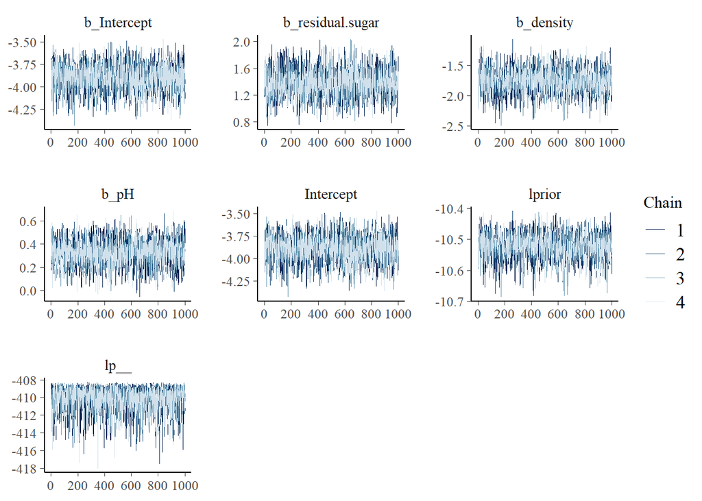

```r
mcmc_trace(as.array(f_mod_s))
```

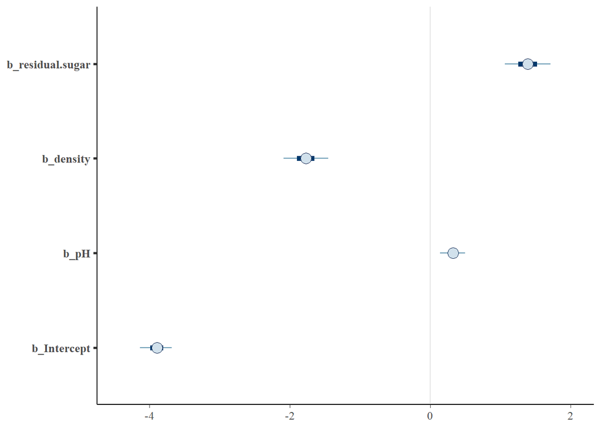

```r
mcmc_intervals(as.array(f_mod_s), pars = c('b_residual.sugar', 'b_density', 'b_pH', 'b_Intercept'))
```

```r
summary(f_a_mod_s)
```

```
##  Family: bernoulli
##   Links: mu = logit
## Formula: wine_quality ~ chlorides + volatile.acidity + sulphates
##    Data: ww_tr[ww_tr$wine_quality == 1, ] (Number of observations: 100)
##   Draws: 4 chains, each with iter = 2000; warmup = 1000; thin = 1;
##          total post-warmup draws = 4000
##
## Regression Coefficients:
##                  Estimate Est.Error l-95% CI u-95% CI Rhat Bulk_ESS Tail_ESS
## Intercept            9.89      2.84     5.33    16.22 1.00     1618     1757
## chlorides            0.72      1.77    -2.30     4.60 1.00     1943     2379
## volatile.acidity     0.25      1.53    -2.50     3.35 1.00     1958     2217
## sulphates            0.30      1.46    -2.33     3.47 1.00     1522     1690
##
## Draws were sampled using sampling(NUTS). For each parameter, Bulk_ESS
## and Tail_ESS are effective sample size measures, and Rhat is the potential
## scale reduction factor on split chains (at convergence, Rhat = 1).
```

```r
loo(f_a_mod_s)
```

```
##
## Computed from 4000 by 100 log-likelihood matrix.
##
##          Estimate  SE
## elpd_loo     -0.5 0.1
## p_loo         0.1 0.0
## looic         0.9 0.2
## ------
## MCSE of elpd_loo is NA.
## MCSE and ESS estimates assume MCMC draws (r_eff in [0.5, 0.8]).
##
## Pareto k diagnostic values:
##                          Count Pct.    Min. ESS
## (-Inf, 0.7]   (good)     99    99.0%   1843
##    (0.7, 1]   (bad)       1     1.0%   <NA>
##    (1, Inf)   (very bad)  0     0.0%   <NA>
## See help('pareto-k-diagnostic') for details.
```

```r
waic(f_a_mod_s)
```

```
##
## Computed from 4000 by 100 log-likelihood matrix.
##
##           Estimate  SE
## elpd_waic     -0.5 0.1
## p_waic         0.1 0.0
## waic           0.9 0.2
```

Again, the effects remain in the smaller model. This time, we see that there is a decrease in both model metrics, implying a marginal increase in performance. I would be wary in this situation because we know that the training set is only A grade wines, and therefore would not likely generalize well. As seen in the plots below, the trace plots don’t display any trends or separations of the different chains. The predictors all cross zero except for the intercept.

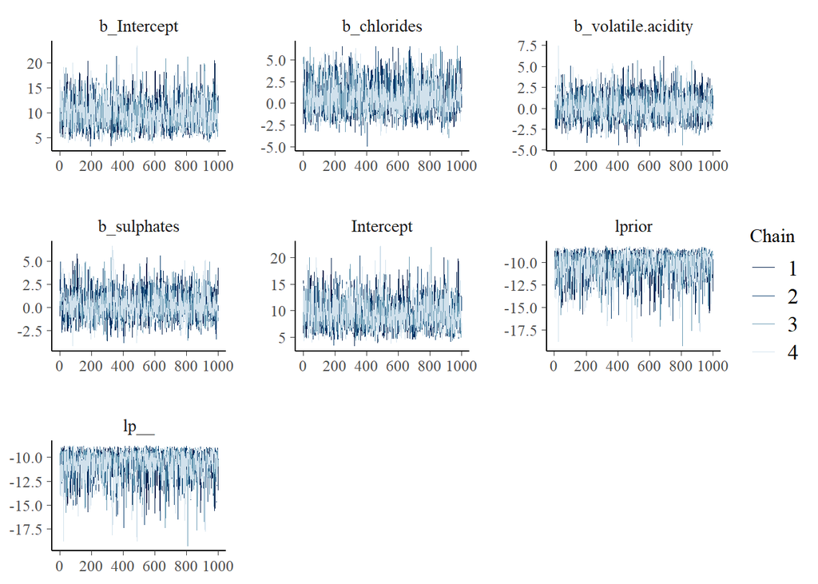

```r
mcmc_trace(as.array(f_a_mod_s))
```

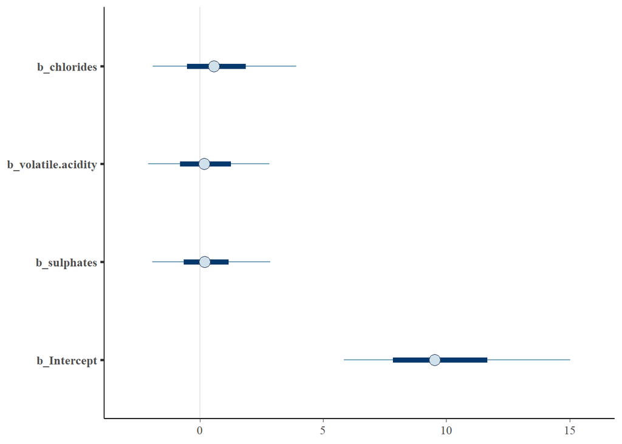

```r
mcmc_intervals(as.array(f_a_mod_s), pars = c('b_chlorides', 'b_volatile.acidity', 'b_sulphates', 'b_Intercept'))
```

```r
p_hat = predict(f_mod_s, newdata = ww_ts, type = "response")
p_hat_a = predict(f_a_mod_s, newdata = ww_ts, type = "response")
library(pROC)
roc_obj <- roc(ww_ts$wine_quality, p_hat[, "Estimate"])
opt_threshold <- coords(roc_obj, "best", ret = "threshold")
print(opt_threshold)
```

```
##   threshold
## 1  0.039125
```

```r
roc_obj_a <- roc(ww_ts$wine_quality, p_hat_a[, "Estimate"])
opt_threshold_a <- coords(roc_obj_a, "best", ret = "threshold")
print(opt_threshold_a)
```

```
##   threshold
## 1  0.997625
```

The method used, Youden’s J Statistic, maximizes the difference between the true positive rate and the false positive rate.

```r
class_hat = ifelse(p_hat[, "Estimate"]>opt_threshold$threshold, 1, 0)
class_hat_a = ifelse(p_hat_a[, "Estimate"]>opt_threshold_a$threshold, 1, 0)

actual_class <- ww_ts$wine_quality
confusion_matrix <- table(Predicted = class_hat, Actual = actual_class)
print(confusion_matrix)
```

```
##          Actual
## Predicted    0    1
##         0 1270   26
##         1  370   54
```

```r
confusion_matrix_a <- table(Predicted = class_hat_a, Actual = actual_class)
print(confusion_matrix_a)
```

```
##          Actual
## Predicted    0    1
##         0  417   29
##         1 1223   51
```

```r
TP <- confusion_matrix[2, 2]
FP <- confusion_matrix[2, 1]
TN <- confusion_matrix[1, 1]
FN <- confusion_matrix[1, 2]

classification_rate <- (TP + TN) / sum(confusion_matrix)

misclassification_rate <- 1 - classification_rate

print(paste("Classification Rate: ", classification_rate))
```

```
## [1] "Classification Rate:  0.769767441860465"
```

```r
print(paste("Misclassification Rate: ", misclassification_rate))
```

```
## [1] "Misclassification Rate:  0.230232558139535"
```

```r
TP <- confusion_matrix_a[2, 2]
FP <- confusion_matrix_a[2, 1]
TN <- confusion_matrix_a[1, 1]
FN <- confusion_matrix_a[1, 2]

classification_rate <- (TP + TN) / sum(confusion_matrix_a)

misclassification_rate <- 1 - classification_rate

print(paste("Classification Rate: ", classification_rate))
```

```
## [1] "Classification Rate:  0.272093023255814"
```

```r
print(paste("Misclassification Rate: ", misclassification_rate))
```

```
## [1] "Misclassification Rate:  0.727906976744186"
```